# Lista01

Heitor Carvalho Pinheiro - 11833351

2022-09-15

## 1ª Lista de exercícios - SME0822

### Exercício 1.1.4

```
## # A tibble: 10 x 4
##    companies           sales profits assets
##    <chr>               <dbl>   <dbl>  <dbl>
##  1 Citigroup           108.    17.0   1484.
##  2 General Electric    152.    16.6    750.
##  3 American Intl Group  95.0   10.9    766.
##  4 Bank of America      65.4   14.1   1110.
##  5 HSBC Group           63.0    9.52  1031.
##  6 ExxonMobil          264.    25.3    195.
##  7 Royal Dutch/Shell   265.    18.5    194.
##  8 BP                  285.    15.7    191.
##  9 ING Group            92.0    8.1   1175.
## 10 Toyota Motor        166.    11.1    211.
```

1. Plot the scatter diagram and marginal dot diagrams for variables x1 and x2. Comment on the appearance of the diagrams.

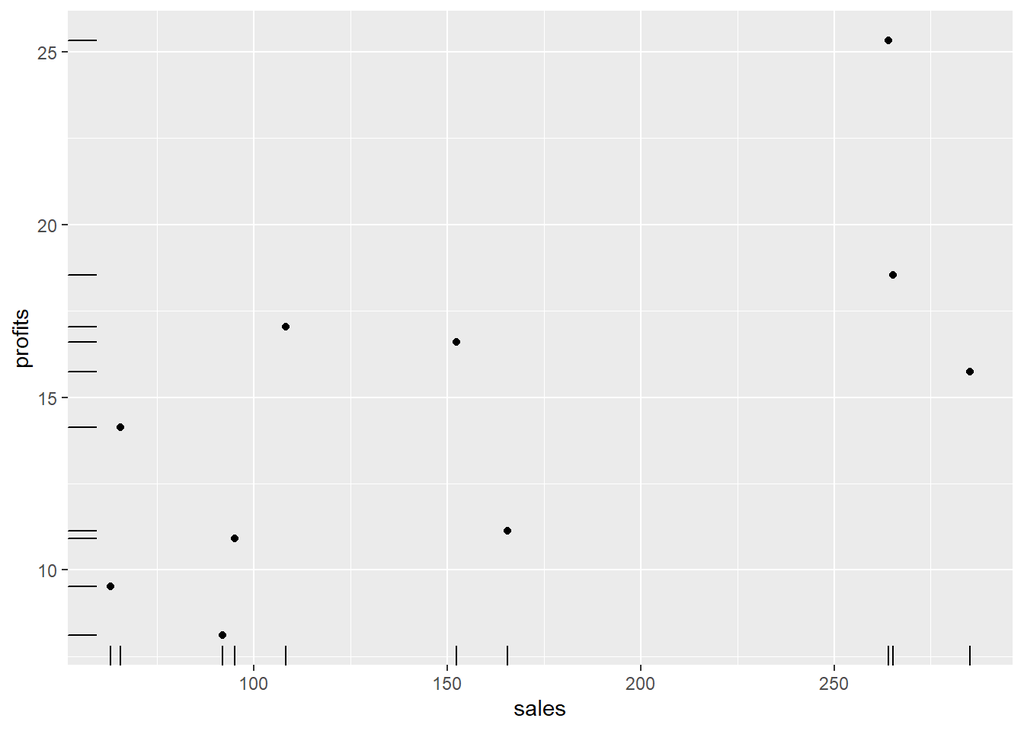

O gráfico de dispersão, visualmente, parece desmonstrar uma correlação positiva entre as variáveis, porém não muito acentuada. Ou seja, conforme as vendas aumentam o lucro também aumenta.

2. Compute $\bar{x}_{1}$, $\bar{x}_{2}$, $s_{11}$, $s_{22}$, $s_{1,2}$ and $r_{12}$. Interprete $r_{12}$

```
## [1] "Media x1 = 155.6"
## [1] "Media x2 = 14.7"
## [1] "Variancia x1 = 7476.45"
## [1] "Variancia x2 = 26.19"
## [1] "Covariancia = 303.62"
## [1] "Correlacao = 0.69"
```

O valor de $r_{12} = 0.69$, confirma a correlação positiva entre as duas variáveis, porém, a correlação não é muito acentuada.

### Exercício 1.1.5

Use the data in 1.1.4

Diagrama de dispersão para ($x_{2}, x_{3}$)

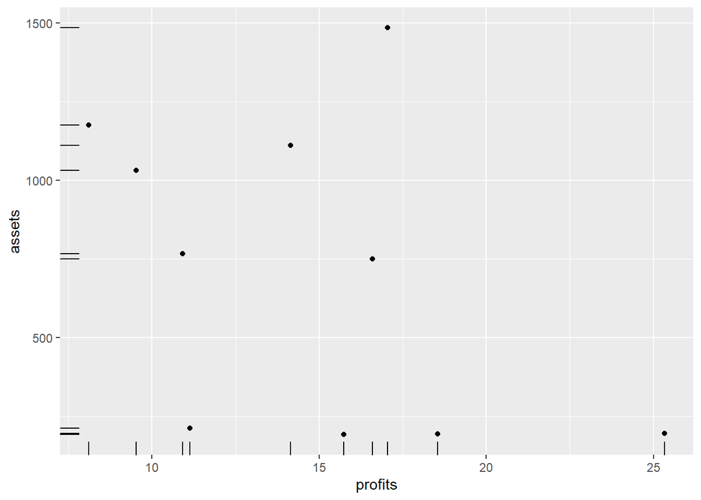

Não parece existir correlação evidente entre o lucro e valor em ações das empresas. Semelhante aos lucros, o valor em ações de cada empresa, possui grande variância, indo de empresas com duas centenas de bilhão em ações a empresas com mais de trilhões em ações.

2. Compute the $\bar{x}$, $S_{n}$ and $\textbf{R}$ arrays for $(x_{1}, x_{2}, x_{3})$

```
## [1] 155.603
```

```
## [1] 14.704
```

```
## [1] 710.911
```

**Vetor de Médias**

$$\begin{bmatrix}
155.6 \\
14.7 \\
711 \\
\end{bmatrix}$$

**Vetor de Correlação**

$$\begin{bmatrix}
1 & 0.69 & -0.84 \\
0.69 & 1 & -0.42 \\
-0.84 & -0.42 & 1 \\
\end{bmatrix}$$

### Exercise 1.1.24

[interactive chart not shown]

**Checking for Outliers**

A análise do Scatterplot em 3D, nos permite identificar 2 outliers facilmente.

- Outlier 1: $(x_1 = 0.11, x_2 = 1.74, x_3=2.49)$
- Outlier 2: $(x_1 = 0.66, x_2 = 11.05, x_3=2.32)$

Também existem métodos quantitativos para detecção de outliers, os quais não abordaremos aqui.

### Exercício 03

1. Avalie se há associação entre as variáveis faixa etária e exame solicitado.

**Verificando a existência de dependência**

```
##
##
##    Cell Contents
## |-------------------------|
## |                       N |
## | Chi-square contribution |
## |           N / Row Total |
## |-------------------------|
##
##
## Total Observations in Table:  1110
##
##
##                   | blood2$`Faixa Etária`
##      blood2$Exame |    18 a 30 anos |    30 a 45 anos | 45 anos ou mais |     Ate 18 anos |       Row Total |
## ------------------|-----------------|-----------------|-----------------|-----------------|-----------------|
## Eletrocardiograma |               6 |              20 |              60 |               6 |              92 |
##                   |           3.976 |           1.262 |           5.192 |           0.632 |                 |
##                   |           0.065 |           0.217 |           0.652 |           0.065 |           0.083 |
## ------------------|-----------------|-----------------|-----------------|-----------------|-----------------|
##        Endoscopia |              24 |             100 |              80 |              10 |             214 |
##                   |           1.520 |          27.086 |           5.583 |           4.466 |                 |
##                   |           0.112 |           0.467 |           0.374 |           0.047 |           0.193 |
## ------------------|-----------------|-----------------|-----------------|-----------------|-----------------|
##            Outros |              30 |              40 |              50 |              24 |             144 |
##                   |           4.116 |           0.001 |           5.741 |           9.373 |                 |
##                   |           0.208 |           0.278 |           0.347 |           0.167 |           0.130 |
## ------------------|-----------------|-----------------|-----------------|-----------------|-----------------|
##            Sangue |             100 |             150 |             350 |              60 |             660 |
##                   |           0.249 |           6.392 |           2.605 |           0.005 |                 |
##                   |           0.152 |           0.227 |           0.530 |           0.091 |           0.595 |
## ------------------|-----------------|-----------------|-----------------|-----------------|-----------------|
##      Column Total |             160 |             310 |             540 |             100 |            1110 |
## ------------------|-----------------|-----------------|-----------------|-----------------|-----------------|
##
##
```

2. Determine e interprete o coeficiente de Tschuprow

Podemos definir o coeficiente de Tschuprow, a apartir da seguinte formula:

$${\displaystyle \phi ^{2}=\sum _{i=1}^{r}\sum _{j=1}^{c}{\frac {(\pi
_{ij}-\pi _{i+}\pi _{+j})^{2}}{\pi _{i+}\pi _{+j}}}}$$

Em que $\phi$ é o coeficiente de contigência da média quadrática.

E ${\displaystyle \pi _{i+}=\sum _{j=1}^{c}\pi _{ij}}$ é o somatório das proporções para a linha $i$ e ${\displaystyle \pi _{+j}=\sum _{i=1}^{r}\pi _{ij}.}$ é o somatório das proporções para a coluna $j$.

Sendo assim, define-se o coeficiente de Tschuprow, da seguinte maneira.

$${\displaystyle T={\sqrt {\frac {\phi ^{2}}{\sqrt {(r-1)(c-1)}}}}.}$$

Perceba que o coeficiente de Tschuprow é uma espécie de normalização do valor de $\phi$.

O coeficiente de Tschuprow $T$ nos indica se existe correlação entre variáveis categóricas em uma tabela de contigência.

Desse modo, um $T>0$ indica que existe correlação, se $T = 0$, não existe correlação. Sendo $0 \leq T \leq1$

O coeficiente de Tschuprow para a tabela de contingência entre Faixa Etária e Exame é:

$$T = 0.15$$

```
##                    Faixa Etária
## Exame               18 a 30 anos 30 a 45 anos 45 anos ou mais Ate 18 anos
##   Eletrocardiograma            6           20              60           6
##   Endoscopia                  24          100              80          10
##   Outros                      30           40              50          24
##   Sangue                     100          150             350          60
```

```
## [1] "integer"
```

```
## [1] 0.1532396
```

O que implica que existe dependência entre as variáveis.

### Exercício 6

Considerando a nossa forma quadrática $2x_1^2-2x_1x_2+x_2^2+4x_1x_3-3x_3^2$, podemos verificar que os valores correspondentes à diagonal principal serão 2,1 e -3. Os valores correspondentes às entradas $(i,j) = (1,2)$ e $(i,j) = (2,1)$ devem resultar em -2, uma vez que temos $-2x_1x_2$, logo, ambos são -1. Por fim o mesmo princípio se aplica às entradas correspodentes a $(i,j) = (1,3)$ e $(i,j) = (3,1)$, como temos que $4x_1x_3$, logo essas entradas recebem o valor 2. As entradas para $(i,j) = (2,3)$ e $(i,j) = (3,2)$ recebem o valor 0.

Por fim, a matriz $A$ associada à forma quadrática é:

### Exercício 7